# Customising Functions

Steve Pederson & Pengyi Yang

7 December 2015

## Customising Functions

### The Tooth Growth Data

The `toothData` file actually contains data about the effects of Vitamin C on tooth growth in Guinea Pigs, using two delivery methods, and three dose levels. The main variable of interest is the length of the teeth, contained in the column `len`. The delivery was done using two different types of Vitamin C supplements, and these are detailed in the `supp` column. The dose levels contained in each supplement are then recorded in the column `dose`, and these represent levels of 0.5, 1 and 2.0mg.

```r
toothData <- read.csv("data/toothData.csv", stringsAsFactors=FALSE)
toothData$supp <- as.factor(toothData$supp)
toothData$dose <- factor(toothData$dose, levels=c("Low", "Med", "High"))
```

### Data Inspection

In keeping with Section 03: Inspecting Data, let’s quickly inspect and plot the data to see what it looks like.

```r
head(toothData)
```

```
##    len supp dose
## 1  4.2   VC  Low
## 2 11.5   VC  Low
## 3  7.3   VC  Low
## 4  5.8   VC  Low
## 5  6.4   VC  Low
## 6 10.0   VC  Low
```

```r
summary(toothData)
```

```
##       len        supp      dose
##  Min.   : 4.20   OJ:30   Low :20
##  1st Qu.:13.07   VC:30   Med :20
##  Median :19.25           High:20
##  Mean   :18.81
##  3rd Qu.:25.27
##  Max.   :33.90
```

```r
nrow(toothData)
```

```
## [1] 60
```

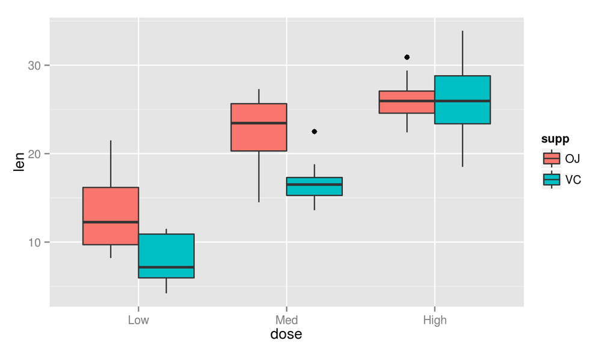

```r
library(ggplot2)
ggplot(toothData, aes(x = dose, y = len, fill = supp)) +
  geom_boxplot()
```

## Writing A Function For Our Needs

Our task is to conduct a `t.test()` for each dose level, to see if there is any effect on tooth length. First, let’s try it for the low dosage level. Remember that for a $T$-test, we have the null and alternate hypotheses:

$H_0$: $\mu_1 = \mu_2$

$H_A$: $\mu_1 \neq \mu_2$

Firstly we could do this by breaking the data into two groups and testing the Null Hypothesis:

```r
lowData <- subset(toothData, dose == "Low")
splitData <- split(lowData, lowData$supp)
g1 <- splitData$OJ$len
g2 <- splitData$VC$len
t.test(g1, g2, alternative = "two.sided")
```

```
##
##  Welch Two Sample t-test
##
## data:  g1 and g2
## t = 3.1697, df = 14.969, p-value = 0.006359
## alternative hypothesis: true difference in means is not equal to 0
## 95 percent confidence interval:
##  1.719057 8.780943
## sample estimates:
## mean of x mean of y
##     13.23      7.98
```

An alternate method would be to use the *R* syntax, for `len` *is dependent on* `supp`, where the tilde `~` can be interpreted with this meaning. We can also subset the data as part of the $T$-test function.

```r
t.test(len ~ supp, data = toothData, subset = dose == "Low")
```

```
##
##  Welch Two Sample t-test
##
## data:  len by supp
## t = 3.1697, df = 14.969, p-value = 0.006359
## alternative hypothesis: true difference in means is not equal to 0
## 95 percent confidence interval:
##  1.719057 8.780943
## sample estimates:
## mean in group OJ mean in group VC
##            13.23             7.98
```

Doing this for all 3 levels will look messy when we email this to our collaborators! Let’s see if we can change the structure of the output to make it look nicer.

First, how does *R* really save the results from the `t.test()` function?

```r
results <- t.test(len ~ supp, data = toothData, subset = dose == "Low")
str(results)
```

```
## List of 9
##  $ statistic  : Named num 3.17
##   ..- attr(*, "names")= chr "t"
##  $ parameter  : Named num 15
##   ..- attr(*, "names")= chr "df"
##  $ p.value    : num 0.00636
##  $ conf.int   : atomic [1:2] 1.72 8.78
##   ..- attr(*, "conf.level")= num 0.95
##  $ estimate   : Named num [1:2] 13.23 7.98
##   ..- attr(*, "names")= chr [1:2] "mean in group OJ" "mean in group VC"
##  $ null.value : Named num 0
##   ..- attr(*, "names")= chr "difference in means"
##  $ alternative: chr "two.sided"
##  $ method     : chr "Welch Two Sample t-test"
##  $ data.name  : chr "len by supp"
##  - attr(*, "class")= chr "htest"
```

This is an *R* object type called a `list`

*What are we really interested in?*

1. The difference in means?
2. The *T*-statistic
3. The degrees of freedom
4. The *p*-value

**Where are these values in the function output?**

We’ll need to calculate the difference in means from the element `$estimate`, but the rest of the objects are in the list elements named `$statistic` `$parameter` & `$p.value`.

We could write a function to output these as a `data.frame`

```r
myToothTest <- function(data){

  # Perform the t.test
  res <- t.test(len~supp, data)

  # Output the data.frame
  data.frame(Difference  = -diff(res$estimate),
             T = res$statistic,
             DF = res$parameter,
             P = res$p.value,
             row.names= NULL)

}
```

Now we can run the function, subsetting the data first.

```r
subData <- subset(toothData, dose == "Low")
myToothTest(subData)
```

```
##   Difference        T       DF           P
## 1       5.25 3.169733 14.96875 0.006358607
```

**This looks much nicer!**

Let’s incorporate the sub-setting into the function, and add the dose level to the output. Note, that some data checking lines have also been introduced to make sure that “Future You”, or a collaborator doesn’t try something silly.

```r
myToothTest <- function(doseLevel, data){

  # Check the structure of the inputs
  stopifnot(doseLevel %in% levels(data$dose))
  stopifnot(is.data.frame(data))
  stopifnot(names(data) %in% c("len", "supp", "dose"))

  # Subset the data
  data <- subset(data, dose == doseLevel)

  # Perform the t.test
  res <- t.test(len~supp, data)

  # Output the data.frame
  data.frame(Dose = doseLevel,
             Difference  = -diff(res$estimate),
             T = res$statistic,
             DF = res$parameter,
             P = res$p.value,
             row.names= NULL)

}
```

Now the function is even easier to run:

```r
myToothTest("Low", toothData)
```

```
##   Dose Difference        T       DF           P
## 1  Low       5.25 3.169733 14.96875 0.006358607
```

## Now the FUN starts

*R* has a function called `lapply()` which applies a function to each element of a vector. As seen on the help page, the results from `lapply()` are as a list, with each element corresponding to the results from each element of the input vector.

First inspect the help page

```r
?lapply
```

As a trivial example, just to see this process in action:

```r
y <- c(1, 16, 2, 9)
lapply(y, FUN = sqrt)
```

```
## [[1]]
## [1] 1
##
## [[2]]
## [1] 4
##
## [[3]]
## [1] 1.414214
##
## [[4]]
## [1] 3
```

**This places each element in the FIRST argument position of the function**.  
First, `lapply()` placed `1` into the first position of the function `sqrt()`. Then it passed `16`, then `2` followed by `9`, and each result was output as a individual element of a `list()` of length 4.

There is a alternate function `sapply()` that simplifies the output where possible

```r
sapply(y, FUN = sqrt)
```

```
## [1] 1.000000 4.000000 1.414214 3.000000
```

It’s very useful, but slightly unpredictable, so use with caution in long, automated procedures or functions.

**Can we use lapply for our different dose levels?**

YES!!! This is why we placed `doseLevels` as the first argument of our function

```r
doseLevels <- levels(toothData$dose)
lapply(doseLevels, myToothTest, data = toothData)
```

```
## [[1]]
##   Dose Difference        T       DF           P
## 1  Low       5.25 3.169733 14.96875 0.006358607
##
## [[2]]
##   Dose Difference       T       DF           P
## 1  Med       5.93 4.03277 15.35767 0.001038376
##
## [[3]]
##   Dose Difference          T       DF         P
## 1 High      -0.08 -0.0461361 14.03982 0.9638516
```

Note that we specified `data = toothData` after the function call. This is where we place any other arguments to the function being called.

## Getting amazing looking output

The *R* package `dplyr` has a function `bind_rows()` for joining identical `data.frame` objects.

First install and/or load the package

```r
install.packages(dplyr)
library(dplyr)
```

```r
doseResults <- lapply(doseLevels, myToothTest, data = toothData)
doseResults <- bind_rows(doseResults)
doseResults
```

```
## Source: local data frame [3 x 5]
##
##    Dose Difference          T       DF           P
##   (chr)      (dbl)      (dbl)    (dbl)       (dbl)
## 1   Low       5.25  3.1697328 14.96875 0.006358607
## 2   Med       5.93  4.0327696 15.35767 0.001038376
## 3  High      -0.08 -0.0461361 14.03982 0.963851589
```

And for those using R Markdown/knitr

```r
library(knitr)
kable(doseResults)
```

| Dose | Difference | T | DF | P |
| --- | --- | --- | --- | --- |
| Low | 5.25 | 3.1697328 | 14.96875 | 0.0063586 |
| Med | 5.93 | 4.0327696 | 15.35767 | 0.0010384 |
| High | -0.08 | -0.0461361 | 14.03982 | 0.9638516 |

## In the real world

This technique can be applied to numerous datasets

- You might want to run the same linear regression model on data from different climates/regions
- You might have thousands of SNPs to run a `fisher.test()` on
- The *R* package `parallel` also has a version of this called `mclapply()` which runs the process in parallel. Whilst there is some overhead as *R* configures each CPU core as an internal node on a cluster, this can greatly speed up results for long functions, or large datasets. The syntax is identical to `lapply()`, making this step-up very simple.